# Stat 371 Homework #6. Solution

Henry Mendoza Rivera, UW-Madison, Department of Statistics.

# 1 Problem 1

At the Hawaii Pineapple Company, the manager is interested in the Weights of the pineapples grown in the company’s fields. Last year, the weight of the pineapples harvested from one large field was roughly normally distributed with a mean of 31 ounces and a standard deviation of 4 ounces. A different irrigation system was installed in this field after the growing season. The Manager wonders if the mean weight of pineapples grown in the field this year will be different from last. The manager collects a simple random sample of Weights 51 from their field this year to test the hypotheses.

33.61, 33.88, 33.11, 37.05, 31.41, 30.69, 33.94, 30.54, 26.04, 36.01, 39.7, 35.6, 34.96, 33.06, 33.63, 34.59, 32.99, 36.08, 32.33, 36.16, 25.06, 35.7, 30.74, 34.33, 40.02, 30.95, 32.68, 36.57, 32.44, 33.58, 26.44, 29.52, 35.39, 37.96, 31.56, 37.47, 34.22, 27.87, 26.08, 30.81,36.86, 32.92, 34.29, 40.86, 33.3, 28.46, 34.1, 35.85, 37.39, 37.8, 35.36

Following the steps given in lecture, test the hypothesis at a $10\%$ significance level.

`Step 1`. State the null and alternative hypotheses and the significance level

1. `Claim:` “The mean weight of pineapples grown in the field this year will be different from last”
2. The name of the variable X=the weight of the pineapples
3. The parameter of interest is: the mean weight of pineapples grown in the field this year
4. The claim in symbolic form is $\mu\ne 31$
5. The claim in symbolic form that must be opposite to the original claim is $\mu=31$
6. The null hypothesis is $H_0:\mu=31$ and the alternative hypothesis is $H_A:\mu\ne 31$.

`Step 2`. Describe the variables

```r
Weights<-c(33.61,   33.88,  33.11,  37.05,  31.41,  30.69,  33.94,  30.54,
           26.04,   36.01,  39.7,   35.6,   34.96,  33.06,  33.63,  34.59,
           32.99,   36.08,  32.33,  36.16,  25.06,  35.7,   30.74,  34.33,
           40.02,   30.95,  32.68,  36.57,  32.44,  33.58,  26.44,  29.52,
           35.39,   37.96,  31.56,  37.47,  34.22,  27.87,  26.08,  30.81,36.86,
           32.92,   34.29,  40.86,  33.3,   28.46,  34.1,   35.85,  37.39,  37.8,   35.36)
```

- Numerical summary.

```r
summary(Weights)
```

```
##    Min. 1st Qu.  Median    Mean 3rd Qu.    Max.
##   25.06   31.48   33.88   33.57   35.93   40.86
```

```r
sd(Weights)
```

```
## [1] 3.578308
```

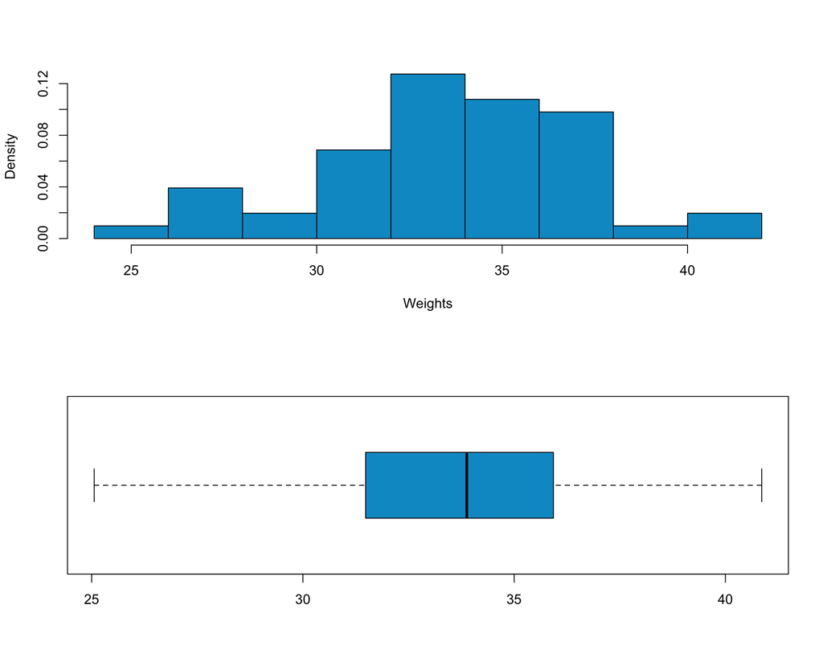

```r
par(mfrow = c(2,1))
hist(Weights, main="",col="deepskyblue3",freq = FALSE)

boxplot(Weights,horizontal = TRUE,col="deepskyblue3")
```

`Step 3`. Check assumptions

Evaluate whether the assumptions of the t test are reasonably met.

- Is the standard deviation known?

No.

- Is the sample small?

We have to assume we have a simple random sample, which we have no way of evaluating aside from taking the manager’s word.

- Do the data come from a normal distribution?.

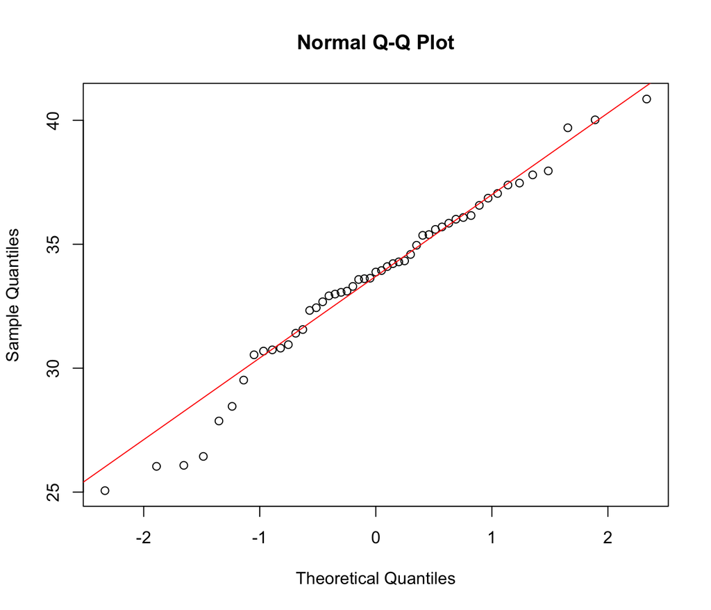

```r
qqnorm(Weights)
qqline(Weights,col="red")
```

- Histogram of sample data is roughly symmetric.
- The qq plot looks roughly linear.

`There is no reason to question normality` for this data.

Either way, with such large sample Weights, we are not as worried about the population being normal assumption. The manager can still believe it is reasonable to assume the distribution of weights for the pineapples is approximately normal.

## 1.1 Solution 1

`Step 4`. Perform the appropriated test statistic and take the decision

- Notice that it was installed a different irrigation system; we should not assume normality based on last year’s information. The new irrigation method could affect the weighs this year. To be safer, we should use the $t$-statistic and assumes that we do not know the standard deviation.

$$\bbox[#ffcc99,20px,border:10px ligth red]
{
T = \frac{\bar{X} - \mu_{0}}{\frac{S}{\sqrt{n}}} \sim T_{(n-1)}
}$$

To take the decision about the null hypothesis we can use either of the following methods:

`Method 1: Rejection region`

Since $\alpha = 0.10$. We put half of $\alpha$ in the tails on either side of the distribution.

The rejection region is defined by:

$$T \le -t_{(n-1,\alpha/2)} \;\textrm{or} \; T \geq t_{(n-1,\alpha/2)}$$

Where $-t_{(n-1,\alpha/2)}$ and $t_{(n-1,\alpha/2)}$ are called the `critical values`. In our case, the critical value $t_{(50,0.95)} = 1.675905$

```r
qt(0.95, 50)
```

```
## [1] 1.675905
```

Then, the `rejection region` is

$$\bbox[#ffcc99,20px,border:10px ligth red]
{
T < -1.675905\; \textrm{or}\; T > 1.675905.
}$$

In R:

```r
tobs<-(mean(Weights)-31)/(sd(Weights)/sqrt(51))
tobs
```

```
## [1] 5.124787
```

`Method 2: Method of p-value`

The p-value is:

$$\bbox[#ffcc99,20px,border:10px ligth red]
{
\textrm{p-value} = P(t_{50} < -5.1247872) + P(t_{50} > 5.1247872) = 4.823998e-06
}$$

In R:

```r
p.valuem1=2*pt(tobs,df=50,lower.tail = FALSE)
p.valuem1
```

```
## [1] 4.823998e-06
```

- Since p-value=4.823998e-06<0.10, we `would reject the null`. Then there is enough statistical evidence to say that the average weight in the population of the pineapples grown in the company’s fields is different of 31 ounces.
- Using the `t.test()` function we have

```r
t.test(Weights, mu=31, alternative="two.sided",conf.level = 0.90)
```

```
##
##  One Sample t-test
##
## data:  Weights
## t = 5.1248, df = 50, p-value = 4.824e-06
## alternative hypothesis: true mean is not equal to 31
## 90 percent confidence interval:
##  32.72811 34.40758
## sample estimates:
## mean of x
##  33.56784
```

`Method 3: Method of Confidence Interval`

- From the last output we have that the $90\%$ confidence interval for $\mu$ that we calculated was $(32.72811, 34.40758)$. Notice that this interval does not contains 31 ounces.
- We observe that the null hypothesis value under $\mu= 31$ is not included in this range of values $(32.72811, 34.40758)$, then there is enough statistical evidence to say that mean Weights of pineapples grown in the company’s fields is `different of 31 ounces`.

`Step 5`. State the conclusion and interpret the decision

We have enough evidence to say that the average weight is different from 31 ounces.

## 1.2 Solution 2: Using the Z-Test with known standard deviation.

Last year, the weight of the pineapples harvested from one large field was roughly normally distributed with a mean of 31 ounces and a standard deviation of 4 ounces, then we will use the z-test. This option is possible, but it is not the best since it assumes that new irrigation does not affect this year’s weight distribution.

`Method 1: Rejection region`

Since $\alpha = 0.10$. We put half of $\alpha$ in the tails on either side of the distribution.

The rejection region is defined by:

$$Z \le -z_{\alpha/2} \;\textrm{or} \; Z \geq z_{\alpha/2}$$

Where $-z_{\alpha/2}$ and $z_{\alpha/2}$ are called the `critical values`. In our case, the critical value $z_{0.95} = 1.644854$

```r
zupper95=qnorm(0.95)
zupper95
```

```
## [1] 1.644854
```

Then, the `rejection region` is

$$\bbox[#ffcc99,20px,border:10px ligth red]
{
Z < -1.644854\; \textrm{or}\; Z > 1.644854.
}$$

Our observed test statistic is:

In R:

```r
tobs<-(mean(Weights)-31)/(4/sqrt(51))
tobs
```

```
## [1] 4.584517
```

The tobs fall in the rejection region $(tobs>1.6448536)$, so we `reject the null hypothesis`.

`Method 2: Method of p-value`

The p-value is:

$$\bbox[#ffcc99,20px,border:10px ligth red]
{
\textrm{p-value} = P(Z < -4.584517) + P(Z > 4.584517) = 4.550371e-06
}$$

In R:

```r
p.valuem2=2*pnorm(tobs,mean=0,sd=1,lower.tail = FALSE)
p.valuem2
```

```
## [1] 4.550371e-06
```

- Since p-value=4.550371e-06<0.10, we `would reject the null hypothesis`. Then there is enough statistical evidence to say that the average weight in the population of the pineapples grown in the company’s fields is different of 31 ounces.

```r
c.lowerzm2=mean(Weights)+c(-1,1)*zupper95*(4/sqrt(51))
c.lowerzm2
```

```
## [1] 32.64654 34.48915
```

`Step 5`. State the conclusion and interpret the decision

We have enough evidence to say that the average weight is different from 31 ounces.

## 1.3 Solution 3: Use the Z-test with the sample standard deviation

This solution assumes the Central Limit Theorem. However, we only have 51 observations, and the CLT is valid for a large sample size.

`Method 1: Rejection region`

Since $\alpha = 0.10$. We put half of $\alpha$ in the tails on either side of the distribution.

The rejection region is defined by:

$$Z \le -z_{\alpha/2} \;\textrm{or} \; Z \geq z_{\alpha/2}$$

Where $-z_{\alpha/2}$ and $z_{\alpha/2}$ are called the `critical values`. In our case, the critical value $z_{0.95} = 1.6448536$

```r
zupper95=qnorm(0.95)
zupper95
```

```
## [1] 1.644854
```

Then, the `rejection region` is
$$Z < -1.644854\; \textrm{or}\; Z > 1.644854.$$

Our observed test statistic is:

In R:

```r
zobs<-(mean(Weights)-31)/(sd(Weights)/sqrt(51))
zobs
```

```
## [1] 5.124787
```

The `zobs` fall in the rejection region $(zobs>1.6448536)$, so we `reject the null hypothesis`.

`Method 2: Method of p-value`

The p-value is:

$$\bbox[#ffcc99,20px,border:10px ligth red]
{
\textrm{p-value} = P(Z< -5.124787) + P(Z > 5.124787) = 2.978739e-07
}$$

In R:

```r
p.valuem3=2*pnorm(zobs,mean=0,sd=1,lower.tail = FALSE)
p.valuem3
```

```
## [1] 2.978739e-07
```

- Since p-value=2.978739e-07<0.10, we `would reject the null hypothesis`. Then there is enough statistical evidence to say that the average weight in the population of the pineapples grown in the company’s fields is different of 31 ounces.

`Method 3: Method of Confidence Interval`

```r
c.lowerz=mean(Weights)+c(-1,1)*zupper95*(sd(Weights)/sqrt(51))
c.lowerz
```

```
## [1] 32.74367 34.39202
```

`Step 5`. State the conclusion and interpret the decision

We have enough evidence to say that the average weight is different from 31 ounces.

# 2 Problem 2.

Using the same information in problem 1:

Perform a bootstrap hypothesis test of $H_0: \mu = 31$ versus $H_A: \mu \ne 31$ at the $10\%$ level.

```r
Weights<-c(33.61,   33.88,  33.11,  37.05,  31.41,  30.69,  33.94,  30.54,
           26.04,   36.01,  39.7,   35.6,   34.96,  33.06,  33.63,  34.59,
           32.99,   36.08,  32.33,  36.16,  25.06,  35.7,   30.74,  34.33,
           40.02,   30.95,  32.68,  36.57,  32.44,  33.58,  26.44,  29.52,
           35.39,   37.96,  31.56,  37.47,  34.22,  27.87,  26.08,  30.81,36.86,
           32.92,   34.29,  40.86,  33.3,   28.46,  34.1,   35.85,  37.39,  37.8,   35.36)
```

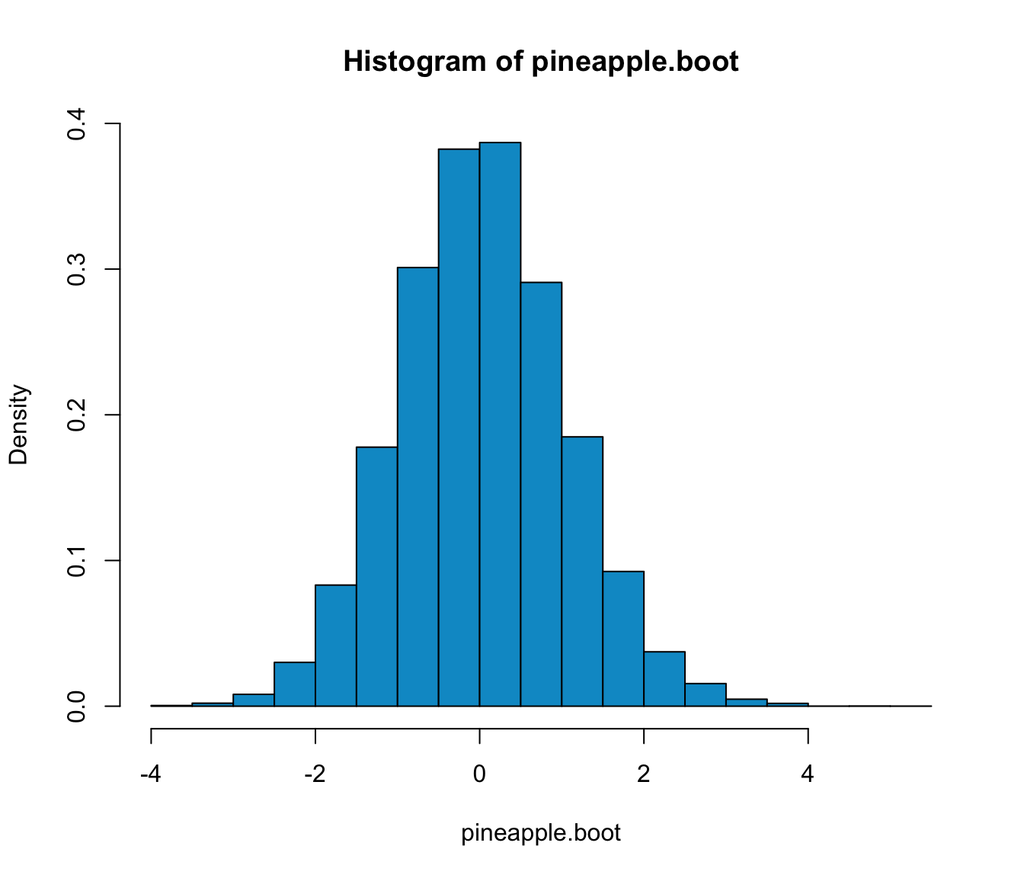

```r
#Create Bootstrap Function
bootstrap = function(x, n.boot) {
  n = length(x)
  x.bar <- mean(x)
  t.hat <- numeric(n.boot) # create vector of length n.boot zeros
  for(i in 1:n.boot) {
    x.star <- sample(x, size=n, replace=TRUE)
    x.bar.star <- mean(x.star)
    s.star <- sd(x.star)
    t.hat[i] <- (x.bar.star - x.bar) / (s.star / sqrt(n))
}
  return(t.hat)
}

pineapple.boot<-bootstrap(Weights, n.boot=30000)
hist(pineapple.boot,col="deepskyblue3",freq = FALSE)
```

```r
x.bar=mean(Weights)
x.sd=sd(Weights)
x.n=length(Weights)
t.obs=(x.bar-31)/(x.sd/sqrt(x.n))
p.value<-(sum(pineapple.boot>=t.obs)+sum(pineapple.boot<=-t.obs))/30000
p.value
```

```
## [1] 3.333333e-05
```

## 2.1 Problem 3

Using the same information in problem 1:

1. Write a statement describing a conclusion of Type I error.

Type I error: It is true that, there is no change in this year’s mean weight, $\mu=31$, but sample evidence leads to conclude that there is a change in this year’s mean weight, $\mu\ne 31$

2. Write a statement describing a conclusion of Type II error.

Type II error: It is true that there is a change in this year’s mean weight, $\mu\ne 31$, but sample evidence leads to conclude that there is no change in this year’s mean weight, $\mu= 31$